# My Daily Eating Habits and Patterns

## Introduction

Eating is something I do every day, but I usually do not stop to think about the pattern behind it. For this project, I used my observational logging data to understand my own eating habits more clearly. The visualization showed what types of meals I logged, where I usually ate, and how my eating flowed across the day.

## Meal Types

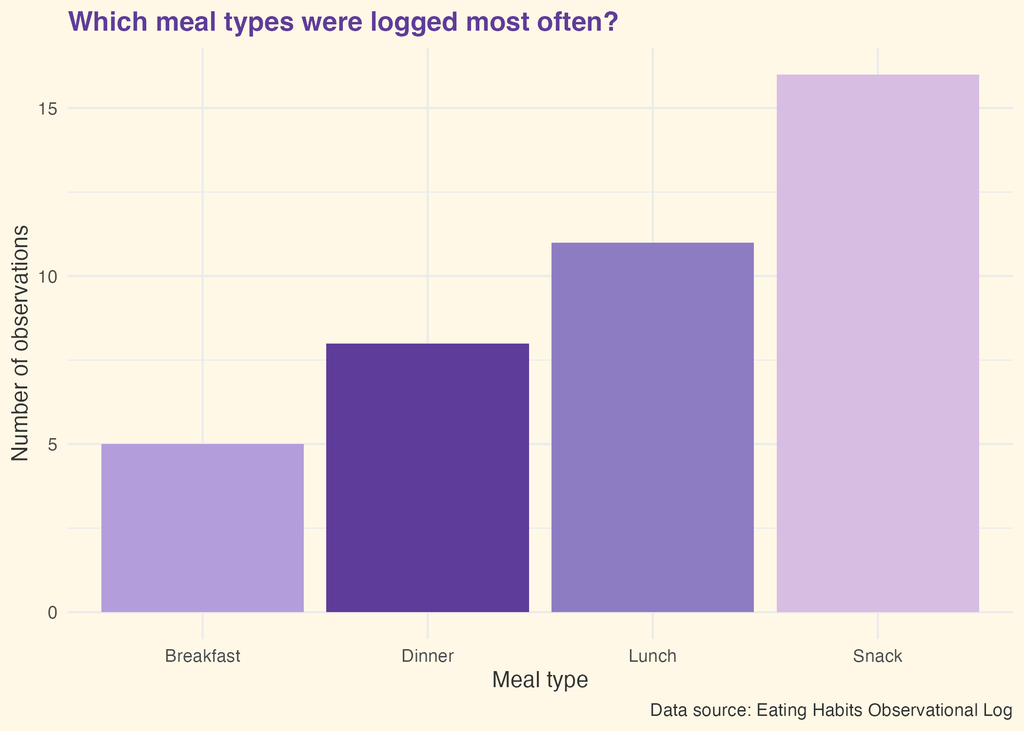

Bar chart showing how often each meal type was logged.

This graph helped me see which meal types appeared most often in my data. It was interesting because eating feels like a normal daily habit, but the graph made the pattern more obvious. I noticed that I logged quite a lot of snacks, which made me think that my eating habits may not be as healthy or balanced as I expected.

## Eating Locations

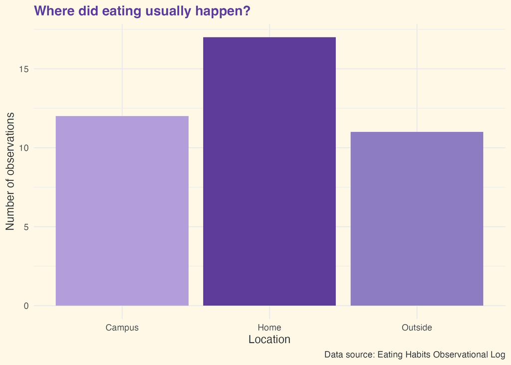

Bar chart showing where eating usually happened.

This graph shows the places where I usually ate. Looking at location helped me connect my eating habits to my daily routine. For example, eating at home, on campus, or outside can reflect what I was doing that day and how busy I was.

## Meal Times

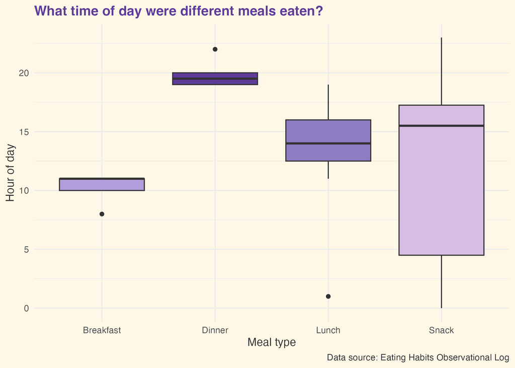

Boxplot showing the eating times for different meal types.

This boxplot shows how my eating flowed across the day. It gives more detail than just counting meals because it shows the spread of eating times. This helped me understand whether my meals followed a regular routine or happened at different times.

## Conclusion

Overall, these ggplots helped me understand my own eating style in a more visual way. Before this project, I did not really notice these patterns because eating is such a basic everyday habit. Turning the data into graphs made my behaviour easier to see and reflect on.